# 6: Analysis of longitudinal data

- Describe your work and results clearly.
- Assume the reader has an introductory course level understanding of writing and reading R code as well as statistical methods.
- Assume the reader has no previous knowledge of your data or the more advanced methods you are using.

## Analysis of RATS data

### Prepare RATS data

```r
library(dplyr)
library(tidyr)
RATS <- read.table("https://raw.githubusercontent.com/KimmoVehkalahti/MABS/master/Examples/data/rats.txt", header = TRUE, sep = '\t')

# Factor variables ID and Group
RATS$ID <- factor(RATS$ID)
RATS$Group <- factor(RATS$Group)

# Convert to long form (RATS)
RATSL <- pivot_longer(RATS, cols = -c(ID, Group),
                      names_to = "WD",
                      values_to = "weight") %>%
         mutate(Time = as.integer(substr(WD, 3, 4))) %>%
         arrange(Time)
```

## Meet and Repeat: PART I

### Individuals on the plot

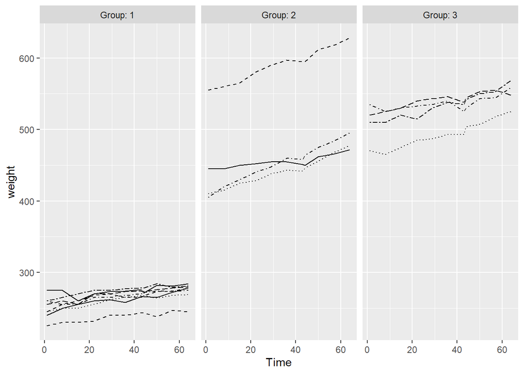

```r
# Access package
library(dplyr)
library(tidyr)
library(ggplot2)

# Draw the plot
ggplot(RATSL, aes(x = Time, y = weight, linetype = ID)) +
  geom_line() +
  scale_linetype_manual(values = rep(1:10, times=4)) +
  facet_grid(. ~ Group, labeller = label_both) +
  theme(legend.position = "none") +
  scale_y_continuous(limits = c(min(RATSL$weight), max(RATSL$weight)))
```

The weights of all groups of rats have increased during the study. Rats with higher weight at the beginning tend to have higher values throughout the study.

### The Golden Standardise

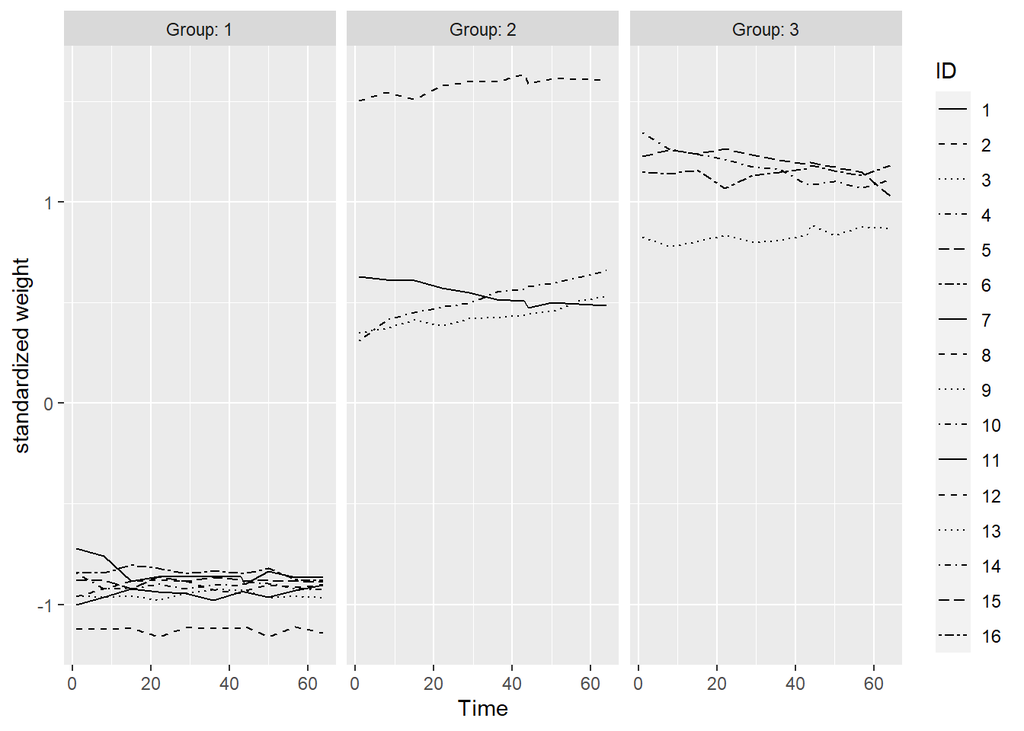

```r
# Standardise the variable weight
RATSL <- RATSL %>%
  group_by(Time) %>%
  mutate(stdweight = (weight - mean(weight))/sd(weight)) %>%
  ungroup()

# Plot again with the standardised weight
library(ggplot2)
ggplot(RATSL, aes(x = Time, y = stdweight, linetype = ID)) +
  geom_line() +
  scale_linetype_manual(values = rep(1:10, times=4)) +
  facet_grid(. ~ Group, labeller = label_both) +
  scale_y_continuous(name = "standardized weight")
```

The weights of rats in all group have changed after standardising. For rats in Group1, their weights tend to keep at the beginning level, and the weights of rats in Group3 has slightly decreased.

### Summary graphs

```r
# Number of subjects (per group):
n <- 16

library(dplyr)
library(tidyr)

# Summary data with mean and standard error of weight by Group and time
RATSS <- RATSL %>%
  group_by(Group, Time) %>%
  summarise( mean = mean(weight), se = (sd(weight)/sqrt(16)) ) %>%
  ungroup()
# Glimpse the data
glimpse(RATSS)
```

```
## Rows: 33
## Columns: 4
## $ Group <fct> 1, 1, 1, 1, 1, 1, 1, 1, 1, 1, 1, 2, 2, 2, 2, 2, 2, 2, 2, 2, 2, 2…
## $ Time  <int> 1, 8, 15, 22, 29, 36, 43, 44, 50, 57, 64, 1, 8, 15, 22, 29, 36, …
## $ mean  <dbl> 250.625, 255.000, 254.375, 261.875, 264.625, 265.000, 267.375, 2…
## $ se    <dbl> 3.805394, 3.273268, 2.868977, 3.400204, 2.764370, 2.945942, 2.73…
```

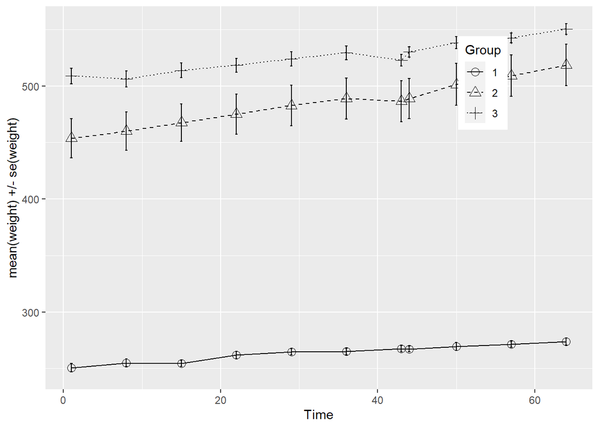

```r
# Plot the mean profiles
library(ggplot2)
ggplot(RATSS, aes(x = Time, y = mean, linetype = Group, shape = Group)) +
  geom_line() +
  scale_linetype_manual(values = c(1,2,3)) +
  geom_point(size=3) +
  scale_shape_manual(values = c(1,2,3)) +
  geom_errorbar(aes(ymin=mean-se, ymax=mean+se, linetype="1"), width=0.3) +
  theme(legend.position = c(0.8,0.8)) +
  scale_y_continuous(name = "mean(weight) +/- se(weight)")
```

As this plot shows, weights of rats has increased during the study, and rats with higher weight at the beginning tend to have higher values throughout the study. The differences in weights of rats in Group 1, 2, 3 tend to keep stable.

### Find the outlaw… Outlier

```r
# Create a summary data by Group and ID with mean as the summary variable
RATSL9S <- RATSL %>%
  filter(Time > 0) %>%
  group_by(Group, ID) %>%
  summarise( mean=mean(weight) ) %>%
  ungroup()
# Glimpse the data
glimpse(RATSL9S)
```

```
## Rows: 16
## Columns: 3
## $ Group <fct> 1, 1, 1, 1, 1, 1, 1, 1, 2, 2, 2, 2, 3, 3, 3, 3
## $ ID    <fct> 1, 2, 3, 4, 5, 6, 7, 8, 9, 10, 11, 12, 13, 14, 15, 16
## $ mean  <dbl> 261.0909, 237.6364, 260.1818, 266.5455, 269.4545, 274.7273, 274.…
```

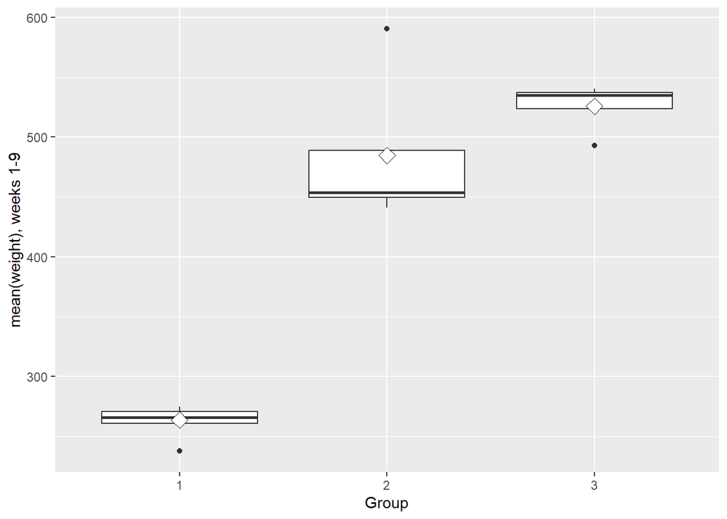

```r
# Draw a boxplot of the mean versus Group
library(ggplot2)
ggplot(RATSL9S, aes(x = Group, y = mean)) +
  geom_boxplot() +
  stat_summary(fun = "mean", geom = "point", shape=23, size=4, fill = "white") +
  scale_y_continuous(name = "mean(weight), weeks 1-9")
```

```r
# Create a new data by filtering the outlier and adjust the ggplot code the draw the plot again with the new data
BPRSL9S1 <- 550

RATSL9S1 <- RATSL9S %>%
  group_by(Group) %>%
  filter(mean < 550) %>%
  ungroup()

# Glimpse the new data
glimpse(RATSL9S1)
```

```
## Rows: 15
## Columns: 3
## $ Group <fct> 1, 1, 1, 1, 1, 1, 1, 1, 2, 2, 2, 3, 3, 3, 3
## $ ID    <fct> 1, 2, 3, 4, 5, 6, 7, 8, 9, 10, 11, 13, 14, 15, 16
## $ mean  <dbl> 261.0909, 237.6364, 260.1818, 266.5455, 269.4545, 274.7273, 274.…
```

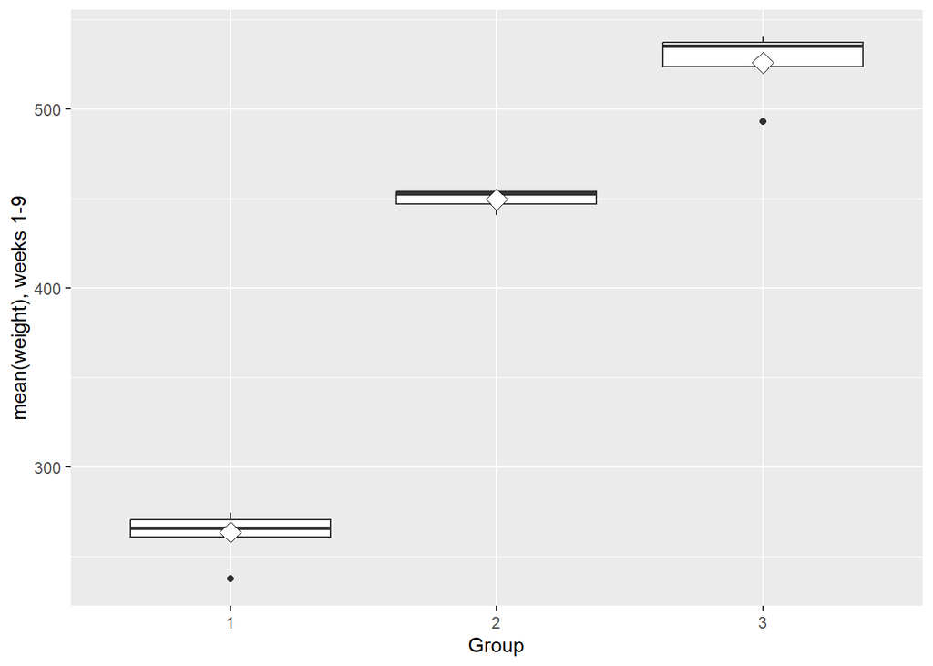

```r
# Draw a boxplot of the new data to check if the outlier has been dealt with
ggplot(RATSL9S1, aes(x = Group, y = mean)) +
  geom_boxplot() +
  stat_summary(fun = "mean", geom = "point", shape = 23, size = 4, fill = "white") +
  scale_y_continuous(name = "mean(weight), weeks 1-9")
```

One outlier was screwed out, the mean weights of rats in Group 1, 2, 3 are about 270 grams, 450 grams, and 525grams seperately.

### T for test and A for Anova (Group 1 and 2)

```r
# Perform a three-sample t-test
RATSL9S1 <- data.frame(
  Group = c(1, 1, 1, 1, 1, 1, 1, 1, 2, 2, 2),
  mean = c(261.0909, 237.6364, 260.1818, 266.5455, 269.4545, 274.7273, 274.6364, 265.4545, 440.8182, 452.7273, 454.81822)
)
t.test(mean ~ Group, data = RATSL9S1)
```

```
##
##  Welch Two Sample t-test
##
## data:  mean by Group
## t = -30.709, df = 5.9527, p-value = 8.748e-08
## alternative hypothesis: true difference in means between group 1 and group 2 is not equal to 0
## 95 percent confidence interval:
##  -200.5670 -170.9104
## sample estimates:
## mean in group 1 mean in group 2
##        263.7159        449.4546
```

```r
# Add the baseline from the original data as a new variable to the summary data
RATSL9S2 <- RATSL9S %>%
  mutate(baseline = RATS$WD1)

# Fit the linear model with the mean as the response
fit <- lm(mean ~ baseline + Group, data = RATSL9S2)

# Compute the analysis of variance table for the fitted model with anova()
anova_table <- anova(fit)
anova_table
```

```
## Analysis of Variance Table
##
## Response: mean
##           Df Sum Sq Mean Sq   F value    Pr(>F)
## baseline   1 252125  252125 2237.0655 5.217e-15 ***
## Group      2    726     363    3.2219   0.07586 .
## Residuals 12   1352     113
## ---
## Signif. codes:  0 '***' 0.001 '**' 0.01 '*' 0.05 '.' 0.1 ' ' 1
```

The Two Sample t-test indicates a significant difference between the means of group 1 and group 2. However, the ANOVA suggests that the overall difference among the three groups (including group 3) is not statistically significant.

### T for test and A for Anova (Group 2 and 3)

```r
RATSL9S1 <- data.frame(
  Group = c(2, 2, 2, 3, 3, 3, 3),
  mean = c(440.8182, 452.7273, 454.81822, 492.9091, 536.2727, 540.1818, 533.8182)
)
t.test(mean ~ Group, data = RATSL9S1)
```

```
##
##  Welch Two Sample t-test
##
## data:  mean by Group
## t = -6.4314, df = 3.8677, p-value = 0.003371
## alternative hypothesis: true difference in means between group 2 and group 3 is not equal to 0
## 95 percent confidence interval:
##  -109.74654  -42.93521
## sample estimates:
## mean in group 2 mean in group 3
##        449.4546        525.7954
```

```r
# Add the baseline from the original data as a new variable to the summary data
RATSL9S2 <- RATSL9S %>%
  mutate(baseline = RATS$WD1)

# Fit the linear model with the mean as the response
fit <- lm(mean ~ baseline + Group, data = RATSL9S2)

# Compute the analysis of variance table for the fitted model with anova()
anova_table <- anova(fit)
anova_table
```

```
## Analysis of Variance Table
##
## Response: mean
##           Df Sum Sq Mean Sq   F value    Pr(>F)
## baseline   1 252125  252125 2237.0655 5.217e-15 ***
## Group      2    726     363    3.2219   0.07586 .
## Residuals 12   1352     113
## ---
## Signif. codes:  0 '***' 0.001 '**' 0.01 '*' 0.05 '.' 0.1 ' ' 1
```

The Two Sample t-test suggests a significant difference between the means of group 2 and group 3, but the ANOVA results indicate that there’s no significant overall difference among the three groups. This discrepancy might be due to the specific pairwise comparison being more sensitive to the differences between certain groups.

## Meet and Repeat: PART II

### BPRS data preparation

```r
library(tidyr)
library(dplyr)

# read in the RATS data
BPRS <- read.table("https://raw.githubusercontent.com/KimmoVehkalahti/MABS/master/Examples/data/BPRS.txt", sep =" ", header = T)

# Factor variables treatment and subject
BPRS$treatment <- factor(BPRS$treatment)
BPRS$subject <- factor(BPRS$subject)

# Convert to long form (BPRS)
BPRSL <-  pivot_longer(BPRS, cols = -c(treatment, subject),
                       names_to = "weeks", values_to = "bprs") %>%
  arrange(weeks)

# Extract the week number
BPRSL <-  BPRSL %>%
            mutate(week = as.integer(substr(weeks, 5,5)))
```

### Draw a plot

```r
# Check the dimensions of the data
dim(BPRSL)
```

```
## [1] 360   5
```

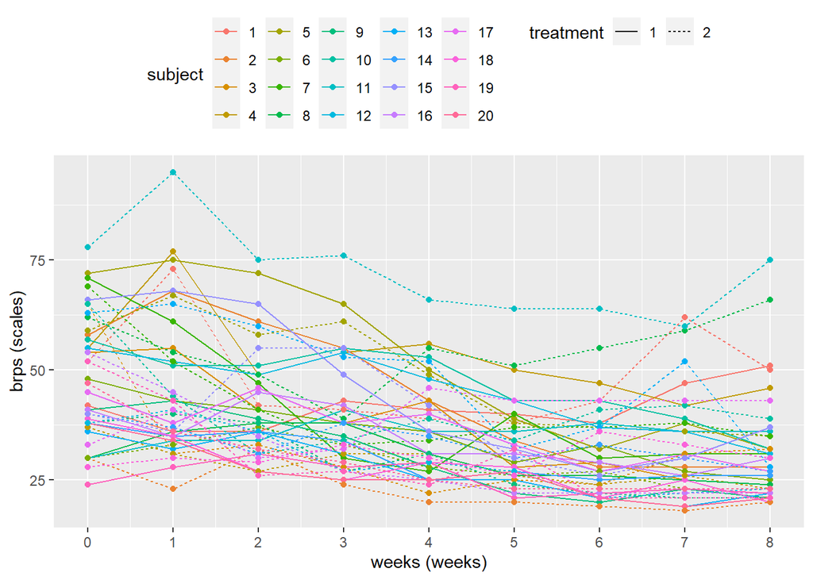

```r
# Plot the RATSL data
library(ggplot2)
ggplot(BPRSL, aes(x = week, y = bprs, color = subject, linetype = treatment)) +
  geom_line()+
  geom_point()+
  scale_x_continuous(name = "weeks (weeks)", breaks = seq(0, 8, 1))+
  scale_y_continuous(name = "brps (scales)")+
  theme(legend.position = "top")
```

The data set BPRSL has 360 observations and 5 variables. The value of brief psychiatric rating scale decreased after 8 weeks’ treatment. The men who have higher BPRS values at the beginning tend to have higher values throughout the study.